# 2020-04-05-formula-one

Kyle Amyx

5/1/2020

## F1 Predictive Modeling

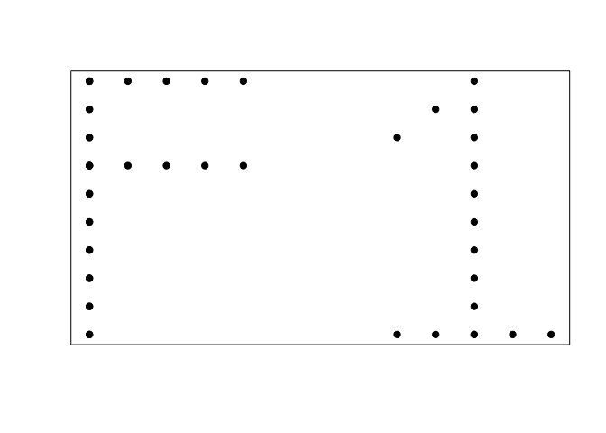

```r
x = c(rep(1,10), 1:5, 1:5, rep(1,10), 9:13, rep(11,10), 9:10)
y <- c(1:10, rep(10, 5), rep(7,5), 1:10, rep(1, 5),  1:10, 8:9)

plot(x,y, pch=19, xlab="", ylab = "", xaxt="n", yaxt="n")
```

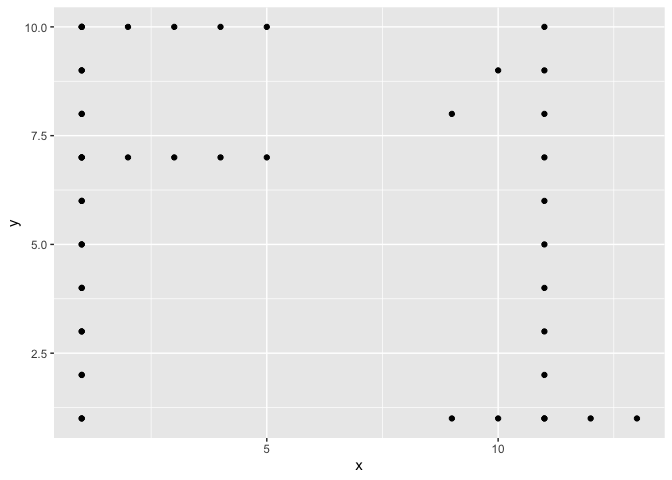

```r
qplot(x= x, y=y)
```

Data is broken down into multiple csv files which will need to be joined on common parameters to gain any insights: * Circuits * Lap Times * Races * Drivers * Driver Standings * Results * More used for reference

```r
circuits = read.csv("Data(1950_2017)/circuits.csv")
lapTimes = read.csv("Data(1950_2017)/lapTimes.csv", stringsAsFactors = FALSE)
races = read.csv("Data(1950_2017)/races.csv", stringsAsFactors = FALSE)
results = read.csv("Data(1950_2017)/results.csv")
drivers = read.csv("Data(1950_2017)/drivers.csv")
driverStandings = read.csv("Data(1950_2017)/driverStandings.csv")
```

Let’s start by exploring the `Drivers` dataset.

```r
# What data types are the features in this set?
sapply(drivers, class)
```

```
##    driverId   driverRef      number        code    forename     surname
##   "integer"    "factor"   "integer"    "factor"    "factor"    "factor"
##         dob nationality         url
##    "factor"    "factor"    "factor"
```

# Drivers

F1 is scored in points, looking at which drivers have the most all-time points. Keep in mind this is dating back to 1950. I’m not familiar if the way Grand Prix are scored has changed. It’s safe to say that for our purpose of predicting future grand prix winners, we will narrow our focus to current drivers. However out of curiousity, let’s look at the all time high scorers.

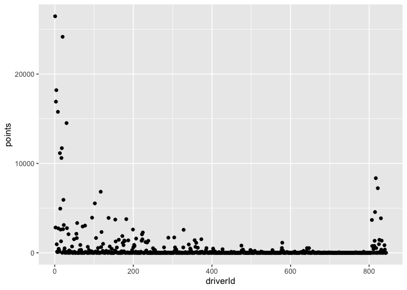

```r
drivers_ = merge(drivers, driverStandings, by="driverId")

driverPoints = drivers_ %>%
  group_by(driverId, driverRef, dob) %>%
  summarize(points = sum(points))

ggplot(data = driverPoints, aes(x=driverId,y=points, label=driverRef)) + geom_point()
```

Too much, cut off at 10,000 points and label

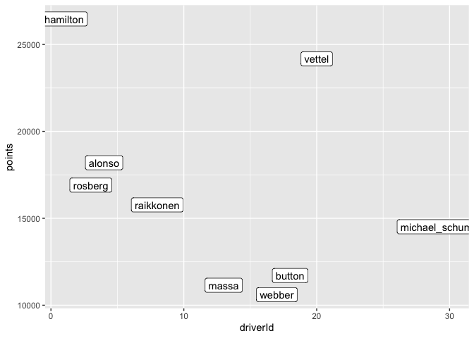

```r
fil = as_tibble(driverPoints) %>%
  select(driverId, points, driverRef) %>%
  group_by(driverId,  driverRef) %>%
  summarise(points = sum(points))
fil = fil[fil$points > 10000,]
  ggplot(data = fil, aes(x=driverId, y = points, label = driverRef)) + geom_point() + geom_label()
```

Not a very good visual, we can better compare the drivers points with a bar/histogram style

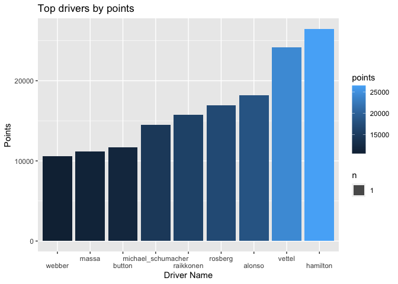

```r
  ggplot(data = fil, aes(x=reorder(driverRef, points), y=points, fill=points)) + geom_bar(stat="sum") + ggtitle("Top drivers by points") +
  xlab("Driver Name") + ylab("Points") +
  scale_x_discrete(labels = function(labels) {
    fixedLabels <- c()
    for(n in 1:length(labels)) {
      fixedLabels[n] <- paste0(ifelse(n %% 2 ==0, "" ,"\n"), labels[n])
    }
    return(fixedLabels)
  })
```

Are all of these drivers still alive and competing?

# Races

```r
summary(races)
```

```
##      raceId          year          round          circuitId
##  Min.   :   1   Min.   :1950   Min.   : 1.000   Min.   : 1.00
##  1st Qu.: 250   1st Qu.:1974   1st Qu.: 4.000   1st Qu.: 9.00
##  Median : 499   Median :1990   Median : 8.000   Median :18.00
##  Mean   : 500   Mean   :1989   Mean   : 8.234   Mean   :21.76
##  3rd Qu.: 748   3rd Qu.:2005   3rd Qu.:12.000   3rd Qu.:30.00
##  Max.   :1009   Max.   :2018   Max.   :21.000   Max.   :73.00
##      name               date               time               url
##  Length:997         Length:997         Length:997         Length:997
##  Class :character   Class :character   Class :character   Class :character
##  Mode  :character   Mode  :character   Mode  :character   Mode  :character
##
##
##
```

Let’s do some EDA on the circuits. Take a look at which races have the shortest lap time.

```r
driver_laps <- merge(races, lapTimes, by = "raceId")
head(driver_laps)
```

```
##   raceId year round circuitId                  name       date   time.x
## 1      1 2009     1         1 Australian Grand Prix 2009-03-29 06:00:00
## 2      1 2009     1         1 Australian Grand Prix 2009-03-29 06:00:00
## 3      1 2009     1         1 Australian Grand Prix 2009-03-29 06:00:00
## 4      1 2009     1         1 Australian Grand Prix 2009-03-29 06:00:00
## 5      1 2009     1         1 Australian Grand Prix 2009-03-29 06:00:00
## 6      1 2009     1         1 Australian Grand Prix 2009-03-29 06:00:00
##                                                       url driverId lap position
## 1 http://en.wikipedia.org/wiki/2009_Australian_Grand_Prix        7   5       15
## 2 http://en.wikipedia.org/wiki/2009_Australian_Grand_Prix        7   6       16
## 3 http://en.wikipedia.org/wiki/2009_Australian_Grand_Prix        7   7       16
## 4 http://en.wikipedia.org/wiki/2009_Australian_Grand_Prix        7   8       16
## 5 http://en.wikipedia.org/wiki/2009_Australian_Grand_Prix        7   9       16
## 6 http://en.wikipedia.org/wiki/2009_Australian_Grand_Prix        7  10       16
##     time.y milliseconds
## 1 1:32.565        92565
## 2 1:33.294        93294
## 3 1:30.891        90891
## 4 1:31.645        91645
## 5 1:52.298       112298
## 6 1:40.160       100160
```

```r
# Only looking at last 10 years
driver_laps <- driver_laps[driver_laps$year > 2008,]
#Add driver name to set
driver_laps <- merge(driver_laps, drivers[,1:2], by = "driverId")
length(unique(driver_laps$circuitId))
```

```
## [1] 26
```

```r
length(unique(driver_laps$raceId))
```

```
## [1] 173
```

```r
temp = driver_laps %>%
  group_by(driverRef, circuitId, raceId, name)

prix_list = races[races$year > 2015,]
prix_list = unique(prix_list$name)

temp = temp[as.character(temp$name) %in% prix_list,]
unique(temp$circuitId)
```

```
##  [1] 73 18 11 10 20  6 15  3 24  4  9  1  7 17  2 70 32 12 13 14 71 22 69
```

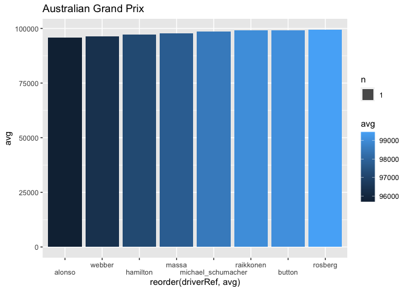

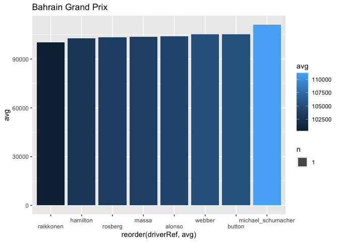

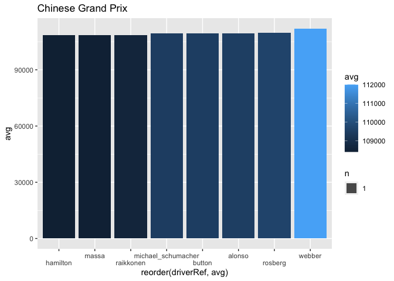

[figure not shown]

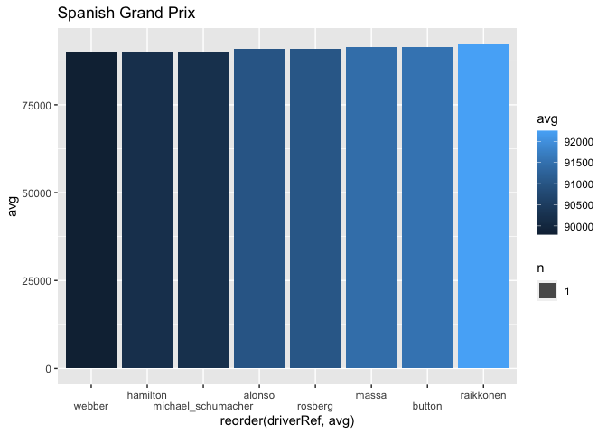

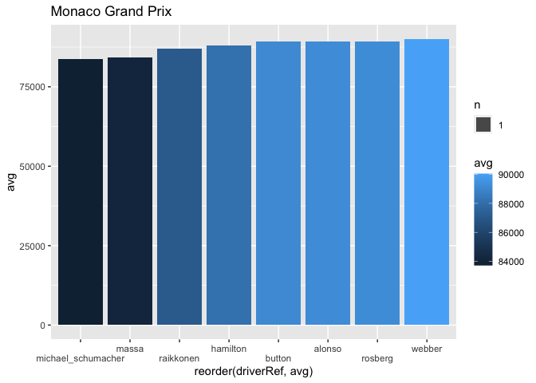

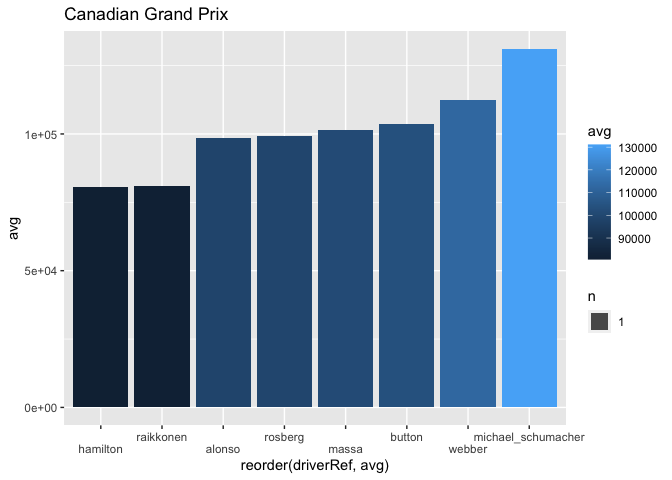

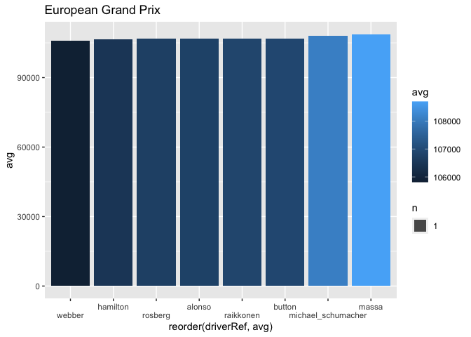

[figure not shown]

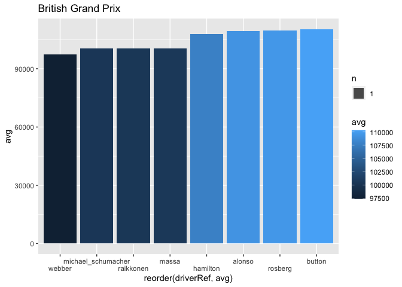

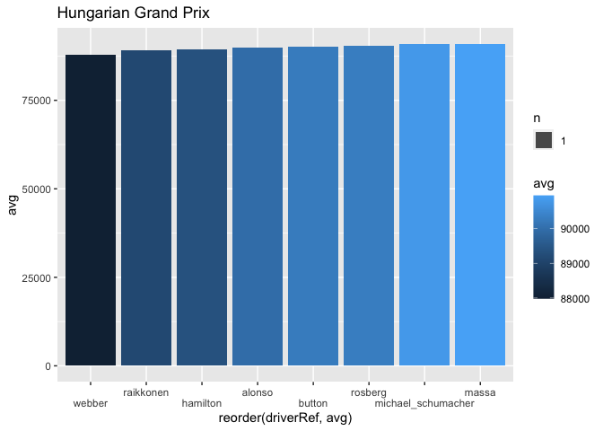

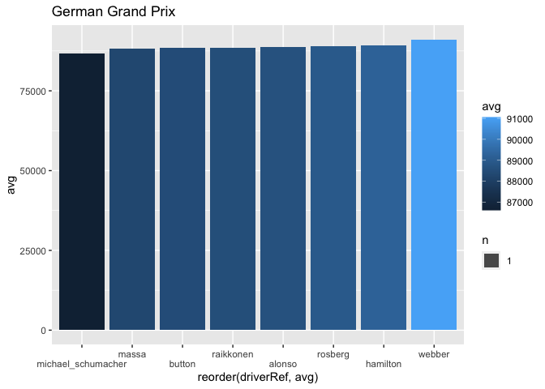

[11 more figures not shown]

```r
for(i in 1:length(prix_list)){
set = temp %>%
  group_by(driverRef) %>%
  filter(driverRef %in% driverId_vec) %>%
  filter(name == prix_list[i]) %>%
  summarise(avg = mean(milliseconds))
  driverLapTimePlot = ggplot(data = set, aes(x= reorder(driverRef,avg), y = avg, fill = avg)) + geom_bar(stat="sum") + ggtitle(prix_list[i]) + scale_x_discrete(labels = function(labels){
    fixedLabels = c()
    for(n in 1:length(labels)){
      fixedLabels[n] = paste0(ifelse(n %% 2 == 0, "", "\n"), labels[n])
    }
    return(fixedLabels)
  }
  )
  print(driverLapTimePlot)
}
```

# Results

```r
summary(results)
```

```
##     resultId         raceId         driverId     constructorId
##  Min.   :    1   Min.   :  1.0   Min.   :  1.0   Min.   :  1.00
##  1st Qu.: 5945   1st Qu.:273.0   1st Qu.: 55.0   1st Qu.:  6.00
##  Median :11889   Median :478.0   Median :154.0   Median : 25.00
##  Mean   :11889   Mean   :487.2   Mean   :226.5   Mean   : 46.28
##  3rd Qu.:17833   3rd Qu.:718.0   3rd Qu.:314.0   3rd Qu.: 57.00
##  Max.   :23781   Max.   :988.0   Max.   :843.0   Max.   :210.00
##
##      number            grid          position       positionText
##  Min.   :  0.00   Min.   : 0.00   Min.   : 1.000   R      :8517
##  1st Qu.:  7.00   1st Qu.: 5.00   1st Qu.: 4.000   F      :1368
##  Median : 15.00   Median :11.00   Median : 7.000   3      : 986
##  Mean   : 16.97   Mean   :11.27   Mean   : 7.782   4      : 986
##  3rd Qu.: 23.00   3rd Qu.:17.00   3rd Qu.:11.000   2      : 984
##  Max.   :208.00   Max.   :34.00   Max.   :33.000   5      : 982
##  NA's   :6                        NA's   :10550    (Other):9954
##  positionOrder       points            laps              time
##  Min.   : 1.00   Min.   : 0.000   Min.   :  0.00           :17773
##  1st Qu.: 7.00   1st Qu.: 0.000   1st Qu.: 20.00   +8:22.19:    5
##  Median :13.00   Median : 0.000   Median : 52.00   +1:29.6 :    4
##  Mean   :13.08   Mean   : 1.601   Mean   : 45.27   0.7     :    4
##  3rd Qu.:19.00   3rd Qu.: 1.000   3rd Qu.: 66.00   46.2    :    4
##  Max.   :39.00   Max.   :50.000   Max.   :200.00   5.7     :    4
##                                                    (Other) : 5983
##   milliseconds        fastestLap         rank       fastestLapTime
##  Min.   : 1474899   Min.   : 2.00   Min.   : 0.0           :18394
##  1st Qu.: 5442948   1st Qu.:29.00   1st Qu.: 5.0    01:17.2:   28
##  Median : 5859428   Median :44.00   Median :11.0    01:16.5:   27
##  Mean   : 6303313   Mean   :41.06   Mean   :10.6    01:16.8:   26
##  3rd Qu.: 6495440   3rd Qu.:53.00   3rd Qu.:16.0    01:28.0:   26
##  Max.   :15090540   Max.   :78.00   Max.   :24.0    01:19.1:   24
##  NA's   :17774      NA's   :18394   NA's   :18246   (Other): 5252
##  fastestLapSpeed    statusId
##         :18394   Min.   :  1.00
##  189.423:    3   1st Qu.:  1.00
##  195.933:    3   Median : 11.00
##  196.785:    3   Mean   : 18.24
##  200.091:    3   3rd Qu.: 16.00
##  201.33 :    3   Max.   :136.00
##  (Other): 5368
```

```r
summary(drivers)
```

```
##     driverId         driverRef       number           code        forename
##  Min.   :  1.0   abate    :  1   Min.   : 2.00          :757   John   : 14
##  1st Qu.:211.2   abecassis:  1   1st Qu.:10.25   BIA    :  2   Mike   : 14
##  Median :421.5   acheson  :  1   Median :21.50   HAR    :  2   Peter  : 13
##  Mean   :421.5   adamich  :  1   Mean   :30.50   MAG    :  2   Bill   : 11
##  3rd Qu.:631.8   adams    :  1   3rd Qu.:38.25   VER    :  2   Tony   : 11
##  Max.   :843.0   ader     :  1   Max.   :99.00   ALB    :  1   Bob    : 10
##                  (Other)  :836   NA's   :804     (Other): 76   (Other):769
##        surname            dob         nationality
##  Taylor    :  5   02/10/1921:  2   British  :162
##  Wilson    :  4   04/09/1920:  2   American :157
##  Brabham   :  3   05/05/1932:  2   Italian  : 99
##  Brown     :  3   06/06/1923:  2   French   : 73
##  Fittipaldi:  3   06/10/1918:  2   German   : 49
##  Hill      :  3   12/12/1946:  2   Brazilian: 31
##  (Other)   :821   (Other)   :830   (Other)  :271
##                                                           url
##                                                             :  1
##  http://en.wikipedia.org/wiki/%C3%89lie_Bayol               :  1
##  http://en.wikipedia.org/wiki/%C3%89ric_Bernard             :  1
##  http://en.wikipedia.org/wiki/%C3%89rik_Comas               :  1
##  http://en.wikipedia.org/wiki/%C3%93scar_Alfredo_G%C3%A1lvez:  1
##  http://en.wikipedia.org/wiki/A.J._Foyt                     :  1
##  (Other)                                                    :836
```

[figure not shown]

[figure not shown]